# LongBet: Randomized Encouragement and Adoption Timing

From encouragement ITTs to exposure-duration effects: identification, randomization inference, sensitivity analysis, and Bayesian diagnostics.

Author

Ignacio Martinez

Published

September 10, 2026

**NoteLongitudinal encouragement in the LongBet suite**

This chapter extends [Randomized Encouragement Design](https://book.martinez.fyi/iv.html) to repeated outcomes and changing adoption. It builds on the panel models in [LongBet](https://book.martinez.fyi/longbet.html), with related material on [decisions](https://book.martinez.fyi/longbet_decisions.html) and [diagnostics](https://book.martinez.fyi/longbet_extensions.html). The examples use the IV development version of LongBet; rendering instructions and the engine revision appear at the end.

**ImportantComparative result**

The repaired implementations run, but the matched study below **does not establish an advantage over adjusted IV**. Neither tested LongBet configuration meets the combined accuracy, coverage, and convergence criteria. The Bayesian extensions remain experimental.

## 1 Start with the business question

An enterprise software team randomizes an offer of concierge onboarding. Accounts choose whether and when to activate a workflow automation tool. The experiment answers two different questions:

- **Should we offer the concierge?** Estimate the effect of assignment on outcomes: the intention-to-treat effect, $\mathrm{ITT}_Y(t)$. Compare the value of that outcome lift with the cost per account assigned the offer.
- **What does using the tool do?** Define the treatment first. Being an adopter this week and having used the tool for four weeks describe different exposures. Identifying their effects requires assumptions beyond randomized assignment.

The distinction matters when encouragement **accelerates adoption**. If an account would adopt in week 2 with the offer and week 4 without it, its adoption status is identical under both assignments by week 4. Its exposure history is still different. An outcome gap can persist after the adoption-rate gap closes.

We will follow one experiment from assigned-arm ITTs to a structural duration model, then examine randomization inference and sensitivity to exclusion. Bayesian smoothing and hazard modeling are optional extensions.

```r
pinned_r_library <- Sys.getenv("LONGBET_R_LIBRARY", "")
library(longbet, lib.loc = if (nzchar(pinned_r_library)) pinned_r_library else NULL)
if (!all(c("engine", "direct_config") %in% names(formals(longbet_encourage)))) {
  stop("This chapter requires the repaired IV interface. Use render-iv.sh to install matching R and Python versions.")
}
library(dplyr)
library(tidyr)
library(tibble)
library(ggplot2)
library(patchwork)
library(knitr)
knitr::opts_chunk$set(cache.extra = list(
  Sys.getenv("LONGBET_ENGINE_REF", "unrecorded"),
  Sys.getenv("LONGBET_RENDER_IMAGE", "unrecorded")
))

set.seed(2026)
theme_set(theme_minimal(base_size = 12))
arm_colors <- c("Control" = "#737373", "Encouraged" = "#2166ac")
fmt <- function(value, digits = 2) formatC(value, format = "f", digits = digits)
```

## 2 Define assignment, adoption, and treatment history

Let $i=1,\ldots,N$ index accounts and $t=1,\ldots,T$ index equally spaced weeks. $Z_i$ is the randomized offer assignment. $D_{it}(z)$ is the account’s potential adoption status under assignment $z$, and $\mathbf D_{i,1:t}(z)$ is its adoption history through week $t$.

We assume adoption is absorbing: once activated, the tool remains available. The duration variable counts weeks since activation, including the activation week:

$$S_{it}(z)=\sum_{s=1}^{t}D_{is}(z).$$

This is exposure to an activated tool, not a measurement of how intensively an account uses it. The sum counts observed weeks; irregular observation times require an explicit definition of elapsed exposure.

Random assignment, consistency, and no interference identify the encouragement ITTs. The exclusion restriction for **treatment history** says that the offer has no outcome effect once that history is held fixed:

$$Y_{it}(z,\mathbf d)=Y_{it}(\mathbf d).$$

This still permits outcomes to depend on duration. A restriction that outcomes depend only on current $d_t$ is stronger. In practice, concierge advice or promotional credits could affect outcomes through channels other than tool activation; later we vary the permitted direct effect.

Horizon-specific monotonicity requires, for every account and week,

$$D_{it}(1)\ge D_{it}(0).$$

The current-adoption complier group is $\{i:D_{it}(1)>D_{it}(0)\}$. Its membership can change with the horizon. An accelerated adopter may be a current-adoption complier in week 2 and an always-adopter under both assignments in week 4. Observed adoption lags do not reveal these individual counterfactual types.

For a binary treatment with relevance, monotonicity, and suitable exclusion assumptions, the familiar Wald ratio identifies a complier average causal effect:

$$\mathrm{CACE}(t)=\frac{\mathrm{ITT}_Y(t)}{\mathrm{ITT}_D(t)}.$$

With duration-dependent outcomes, those assumptions must be reconsidered for the treatment being placed in the denominator. Dynamic compliance and exposure are also the focus of [Angrist et al.’s longitudinal IV framework](https://arxiv.org/abs/2501.01623).

## 3 Simulate an encouragement experiment

We observe 300 accounts over six weeks, with one randomized encouragement wave in week 2 and a permanent holdout. Potential adoption paths have three patterns: early adopters activate in week 1 under either assignment; accelerated adopters activate in week 2 with encouragement and week 4 without it; and non-adopters remain inactive throughout the study. Their expected shares are 15%, 55%, and 30%.

An unobserved readiness variable determines the adoption pattern and also raises untreated engagement. This creates selection into adoption. The offer is randomized independently of readiness. Control accounts adopt on their own schedule; there are no spillovers between accounts.

We construct both potential outcome panels **before drawing assignment**, using the same untreated outcome shocks under both assignments. The structural response is deliberately simple: each extra week of exposure raises the current week’s active-user hours by 10. This lets us distinguish estimation error from a change in the target.

```r
N <- 300L
T_len <- 6L
t_grid <- seq_len(T_len)
t_enc <- 2L
true_beta_duration <- 10
success_threshold <- 85  # Prespecified business target: 85 active-user hours/week

readiness <- rnorm(N)
types <- ifelse(readiness > qnorm(0.85), "early",
                ifelse(readiness < qnorm(0.30), "never", "accelerated"))
x <- cbind(
  team_size = pmax(1, round(rnorm(N, 20, 5))),
  baseline_activity = round(rnorm(N, 45, 10), 1)
)

# Each account has two potential activation dates.
adopt_0 <- ifelse(types == "early", 1, ifelse(types == "never", Inf, 4))
adopt_1 <- ifelse(types == "early", 1, ifelse(types == "never", Inf, 2))
d0 <- outer(adopt_0, t_grid, function(a, tt) as.numeric(tt >= a))
d1 <- outer(adopt_1, t_grid, function(a, tt) as.numeric(tt >= a))
s0 <- t(apply(d0, 1, cumsum))
s1 <- t(apply(d1, 1, cumsum))

# Readiness is a common cause of adoption and untreated outcomes.
unit_base <- 25 + 8 * readiness + rnorm(N, 0, 4) +
  0.8 * x[, "team_size"] + 0.5 * x[, "baseline_activity"]
calendar_trend <- 3 * (t_grid - 1)
y_base <- outer(unit_base, calendar_trend, "+") +
  matrix(rnorm(N * T_len, 0, 3), N, T_len)
y0 <- y_base + true_beta_duration * s0
y1 <- y_base + true_beta_duration * s1

# Complete randomization, after potential outcomes have been fixed.
z_unit <- sample(rep(c(0, 1), each = N / 2))
z <- outer(z_unit, as.numeric(t_grid >= t_enc))
d <- d0 + z_unit * (d1 - d0)
y <- y0 + z_unit * (y1 - y0)
duration <- s0 + z_unit * (s1 - s0)

# Simulation truth is averaged over the same finite set of accounts.
truth <- tibble(
  period = t_grid,
  itt_d = colMeans(d1 - d0),
  itt_s = colMeans(s1 - s0),
  itt_y = colMeans(y1 - y0)
)
stopifnot(all(d1 >= d0), all(s1 >= s0),
          all(abs(truth$itt_y - true_beta_duration * truth$itt_s) < 1e-10),
          all(abs((y1 - true_beta_duration * d1)[, t_enc] -
                  (y0 - true_beta_duration * d0)[, t_enc]) < 1e-10),
          truth$itt_d[4] == 0, truth$itt_s[4] > 0)
```

### 3.1 Validate the observed panel

`validate_encouragement()` checks the supported panel structure, including binary absorbing indicators, the common encouragement wave, and the holdout. It does not verify randomization, exclusion, or individual monotonicity; those require the design and a causal argument. Pre-encouragement adoption is permitted.

```r
validation <- validate_encouragement(z, d, t = t_grid)
as.data.frame(validation)
```

```
                design n_units n_periods n_encouraged n_control
1 single_wave_complete     300         6          150       150
  encouragement_period encouragement_index has_pre_periods perfect_compliance
1                    2                   1            TRUE              FALSE
```

The reference analysis below assumes complete individual randomization. For blocked, clustered, or unequal-probability assignment, declare the actual design with `encouragement_design()` and use `design_encouragement_effects()`. The AR function demonstrated here supports complete individual randomization only.

## 4 Begin with the assigned-arm ITTs

`encouragement_summary()` describes adoption by randomized arm. `encouragement_effects()` estimates outcome and adoption ITTs and their joint uncertainty. These are differences in assigned-arm means; actual adoption is not treated as an unconfounded exposure.

```r
uptake <- encouragement_summary(z, d, t = t_grid)
reference <- encouragement_effects(y, d, z, t = t_grid)

reference %>%
  select(period, horizon, itt_y, itt_y_se, itt_d, itt_d_se) %>%
  kable(digits = 3,
        col.names = c("Week", "Horizon", "Outcome ITT", "SE", "Adoption ITT", "SE"))
```

| Week | Horizon | Outcome ITT | SE | Adoption ITT | SE |
| --- | --- | --- | --- | --- | --- |
| 2 | 1 | 8.530 | 1.824 | 0.627 | 0.044 |
| 3 | 2 | 14.324 | 2.144 | 0.627 | 0.044 |
| 4 | 3 | 15.704 | 2.498 | 0.060 | 0.052 |
| 5 | 4 | 15.731 | 2.937 | 0.060 | 0.052 |
| 6 | 5 | 16.886 | 3.406 | 0.060 | 0.052 |

Week 2 is horizon 1. Its estimated outcome ITT is 8.53 active-user hours per account assigned the offer, and its estimated adoption ITT is 62.7 percentage points. The ITT answers the offer-policy question even if exclusion fails. Converting hours to monetary value requires a separate business valuation.

### 4.1 Three views of the same experiment

The aligned panels in Figure 1 show adoption rates, accumulated exposure, and the outcome ITT. The outcome error bars are pointwise normal reference intervals. The dashed outcome curve is known only because these are simulated data.

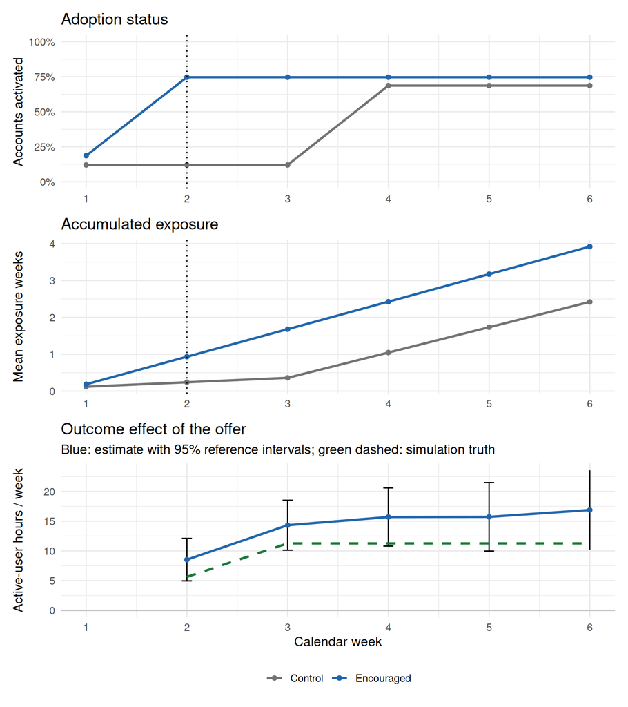

Figure 1: Adoption stocks can converge while exposure differences and outcome effects persist. The bottom panel compares the estimated outcome ITT with its finite-sample simulation truth.

```r
arm_paths <- bind_rows(lapply(c(0, 1), function(arm_value) {
  tibble(period = t_grid,
         arm = if (arm_value == 1) "Encouraged" else "Control",
         adoption = colMeans(d[z_unit == arm_value, , drop = FALSE]),
         exposure = colMeans(duration[z_unit == arm_value, , drop = FALSE]))
}))

p_adoption <- ggplot(arm_paths, aes(period, adoption, color = arm)) +
  geom_line(linewidth = 1) + geom_point() +
  geom_vline(xintercept = t_enc, linetype = "dotted") +
  scale_color_manual(values = arm_colors) +
  scale_y_continuous(labels = scales::label_percent(), limits = c(0, 1)) +
  labs(title = "Adoption status", x = NULL, y = "Accounts activated", color = NULL)
p_exposure <- ggplot(arm_paths, aes(period, exposure, color = arm)) +
  geom_line(linewidth = 1) + geom_point() +
  geom_vline(xintercept = t_enc, linetype = "dotted") +
  scale_color_manual(values = arm_colors) +
  labs(title = "Accumulated exposure", x = NULL, y = "Mean exposure weeks", color = NULL)
p_outcome <- ggplot(reference, aes(period, itt_y)) +
  geom_hline(yintercept = 0, color = "grey75") +
  geom_errorbar(aes(ymin = itt_y - qnorm(0.975) * itt_y_se,
                    ymax = itt_y + qnorm(0.975) * itt_y_se), width = 0.10) +
  geom_line(color = "#2166ac", linewidth = 1) + geom_point(color = "#2166ac") +
  geom_line(data = filter(truth, period >= t_enc),
            color = "#1b7837", linetype = "dashed", linewidth = 1) +
  labs(title = "Outcome effect of the offer", x = "Calendar week",
       y = "Active-user hours / week",
       subtitle = "Blue: estimate with 95% reference intervals; green dashed: simulation truth")
(p_adoption / p_exposure / p_outcome) +
  plot_layout(guides = "collect") &
  scale_x_continuous(breaks = t_grid, limits = range(t_grid)) &
  theme(legend.position = "bottom")
```

At week 1, the sample adoption difference is 0.067, even though the true assignment effect is zero. At week 4, the true adoption ITT is again zero because every account has the same adoption status under both assignments. The observed arm difference is 0.060. Randomization does not guarantee identical compositions in the two realized arms.

The week-4 true exposure ITT is 1.13 weeks per account, and the true outcome ITT is 11.27 hours. Those persist because accelerated accounts have two extra weeks of exposure.

## 5 Why current adoption can be the wrong denominator

Two issues need separate treatment:

| Issue | What goes wrong? | What the analysis needs |
| --- | --- | --- |
| Weak first stage | A small, uncertain denominator makes ratio inference unstable. | Inference appropriate to the assignment mechanism and null hypothesis. |
| Incomplete treatment definition | Current adoption omits outcome-relevant treatment history. | An explicit history or duration estimand and identification assumptions. |

A confidence procedure cannot repair an inadequate treatment definition. In this simulation, the week-2 sharp ratio is 10 because encouragement adds one exposure week when it changes adoption. At week 3 it is 20. From week 4 onward, accelerated accounts have $D_{it}(1)-D_{it}(0)=0$ and $Y_{it}(1)-Y_{it}(0)=20$. No finite coefficient on current adoption can describe that assignment effect.

### 5.1 Preserve the complete reference confidence set

LongBet’s reference set inverts an asymptotic normal test for the assigned-arm contrast in $Y-\beta D$, using the joint covariance of both ITTs. This Fieller-type construction is different from a symmetric, delta-method interval around a ratio. It can produce bounded, disjoint, all-real, or empty sets, among other cases. It is pointwise and asymptotic, not a finite-sample permutation result.

```r
# Format both components; a missing second component means there is only one.
format_set <- function(kind, lower1, upper1, lower2, upper2) {
  if (kind == "all_real") return("(-Inf, Inf)")
  if (kind == "empty") return("Empty")
  if (kind == "unavailable") return("Unavailable")
  component <- function(lo, hi) paste0(if (is.infinite(lo)) "(" else "[",
    fmt(lo), ", ", fmt(hi), if (is.infinite(hi)) ")" else "]")
  parts <- component(lower1, upper1)
  if (!is.na(lower2) && !is.na(upper2)) parts <- c(parts, component(lower2, upper2))
  paste(parts, collapse = " U ")
}
reference_sets <- reference %>%
  rowwise() %>%
  mutate(confidence_set = format_set(wald_set_type, wald_lower_1, wald_upper_1,
                                     wald_lower_2, wald_upper_2)) %>%
  ungroup()
reference_sets %>%
  select(period, wald, wald_set_type, confidence_set) %>%
  kable(digits = 2, col.names = c("Week", "Sample Wald ratio", "Set type", "95% reference set"))
```

| Week | Sample Wald ratio | Set type | 95% reference set |
| --- | --- | --- | --- |
| 2 | 13.61 | bounded | [8.66, 17.99] |
| 3 | 22.86 | bounded | [17.90, 27.20] |
| 4 | 261.74 | disjoint | (-Inf, -282.76] U [115.40, Inf) |
| 5 | 262.19 | disjoint | (-Inf, -257.35] U [122.05, Inf) |
| 6 | 281.43 | disjoint | (-Inf, -259.52] U [135.85, Inf) |

The week-4 sample ratio is 261.74, with a disjoint reference set. A noisy sample denominator need not equal its zero population target. Read this result alongside the treatment-history argument: its numerical value does not identify a week-4 current-adoption CACE. An unbounded or disjoint set should be reported in full.

## 6 Estimate an exposure-duration response

Suppose a common duration response is scientifically plausible:

$$Y_{it}=\alpha_i+\lambda_t+g(S_{it})+\varepsilon_{it},\qquad
g(S)=\beta S.$$

Here $g(S)$ is the effect on **this week’s outcome** after $S$ weeks of exposure. It is not an outcome summed over all prior weeks. Under this model and valid randomized instruments,

$$\mathrm{ITT}_Y(t)=\beta\,\mathrm{ITT}_S(t).$$

This is the bridge between the last two panels of Figure 1. In our finite population it holds exactly by construction. In a realized experiment, the estimated contrasts have sampling error.

`duration_deconvolution_effects()` implements conventional panel 2SLS by removing unit and calendar means and instrumenting duration regressors with assignment-by-post-period terms. The repaired implementation uses an account-clustered CR1 sandwich covariance, counts absorbed fixed effects in its degrees of freedom, and uses $t_{N-1}$ critical values. It rejects unidentified designs and nonzero ridge penalties. This implements an established IV estimator for an explicitly defined exposure; it does not create a new source of identification.

The causal interpretation requires exclusion through the modeled history, an adequate duration-response specification, valid instrument moments, and enough independent instrument variation to identify the chosen response parameters. A flexible response needs a rank argument; regularization cannot supply missing identification. The linear option estimates one slope and imposes a straight response curve. It does not discover that shape from the data.

```r
deconv_fit <- duration_deconvolution_effects(
  y = y, d = d, z = z, t = t_grid, model_type = "linear", alpha = 0.05
)
deconv_fit$summary_table %>%
  select(duration, cumulative_effect, ci_lower, ci_upper) %>%
  kable(digits = 2, col.names = c("Exposure weeks", "Effect on current weekly hours",
                                 "95% lower", "95% upper"))
```

| Exposure weeks | Effect on current weekly hours | 95% lower | 95% upper |
| --- | --- | --- | --- |
| 1 | 9.82 | 9.22 | 10.43 |
| 2 | 19.65 | 18.44 | 20.85 |
| 3 | 29.47 | 27.67 | 31.28 |
| 4 | 39.30 | 36.89 | 41.70 |
| 5 | 49.12 | 46.11 | 52.13 |
| 6 | 58.94 | 55.33 | 62.55 |

The estimated slope is 9.82 additional active-user hours in the current week per extra exposure week, with a 95% interval of [9.22, 10.43]. The simulation slope is 10.00.

The fitted model has instrument rank 5 and instrumented-regressor rank 1. Its first-stage diagnostic status is **singular cluster covariance**. The scalar diagnostic, when available, is a cluster Wald statistic divided by instrument rank. A singular cluster covariance yields an explicit unavailable result; it does not justify substituting an ordinary $F$ statistic. Multiple duration regressors require a joint strength assessment that this function does not provide.

```r
deconv_fit$first_stage_diagnostics %>%
  select(regressor, cluster_wald_f, partial_r_squared) %>%
  kable(digits = 2, col.names = c("Duration term", "Cluster Wald / rank", "Partial R-squared"))
```

| Duration term | Cluster Wald / rank | Partial R-squared |
| --- | --- | --- |
| duration | NaN | 0.13 |

Do not apply a universal cutoff of 10. Applicable critical values depend on the statistic, design, and inferential criterion; see [Andrews, Stock, and Sun](https://economics.mit.edu/sites/default/files/2023-06/wirev_092218-_corrected_0.pdf). The duration intervals remain conventional strong-instrument approximations. Full rank alone is insufficient for reliable inference with a weak first stage.

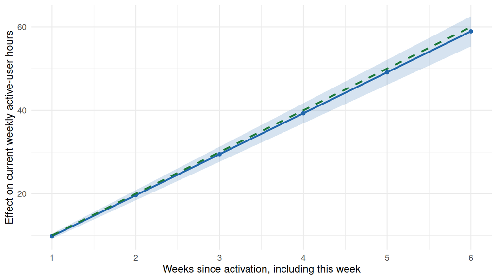

Figure 2: The fitted linear duration response and pointwise 95% intervals. The dashed line is the known simulation response; linearity is imposed by the fitted model.

```r
ggplot(deconv_fit$summary_table, aes(duration, cumulative_effect)) +
  geom_ribbon(aes(ymin = ci_lower, ymax = ci_upper), fill = "#2166ac", alpha = 0.18) +
  geom_line(color = "#2166ac", linewidth = 1) + geom_point(color = "#2166ac") +
  geom_line(aes(y = duration * true_beta_duration),
            color = "#1b7837", linetype = "dashed", linewidth = 1) +
  scale_x_continuous(breaks = deconv_fit$durations) +
  labs(x = "Weeks since activation, including this week",
       y = "Effect on current weekly active-user hours")
```

## 7 Randomization inference: specify the sharp null

Return to **week 2**, where each accelerated account gains one exposure week. Our constant-effect construction satisfies the sharp null at $\beta_0=10$:

$$H_0(\beta_0):\quad
Y_{it}(1)-\beta_0D_{it}(1)
=Y_{it}(0)-\beta_0D_{it}(0)\quad\text{for every }i.$$

Under this null, $R_{it}(\beta_0)=Y_{it}-\beta_0D_{it}$ is fixed across allowed assignments. `randomization_ar()` compares the observed absolute studentized arm difference with its randomization distribution. This supports finite-sample-valid testing even with a weak first stage. It does **not** give exact inference for an unrestricted heterogeneous CACE, nor does it make the sharp current-adoption model appropriate at later horizons.

Full enumeration gives exact randomization p-values. Here the assignment space is too large, so we sample assignments and use the function’s finite-sample-valid Monte Carlo correction: add one to the number of exceedances and divide by one plus the number of sampled assignments. Monte Carlo p-values still vary with the sampled assignments. [Kang, Peck, and Keele](https://academic.oup.com/jrsssa/article/181/4/1231/7072052) discuss the distinction between exact and approximate IV randomization procedures.

```r
beta_grid <- seq(-10, 30, by = 0.5)
# Only supply the baseline and first follow-up: later horizons have different nulls.
ar_result <- randomization_ar(
  y = y[, 1:2], d = d[, 1:2], z = z[, 1:2], t = t_grid[1:2],
  beta = beta_grid, alpha = 0.05, method = "monte_carlo",
  permutations = 1999L, seed = 42L
)
ar_table <- ar_result$table %>% arrange(beta)
ar_truth <- ar_table %>% filter(beta == true_beta_duration)

# Report consecutive accepted grid runs, preserving gaps and empty results.
ar_runs <- ar_table %>%
  mutate(run = cumsum(accepted != lag(accepted, default = first(accepted)))) %>%
  filter(accepted) %>%
  group_by(run) %>%
  summarise(first_accepted = min(beta), last_accepted = max(beta),
            grid_points = n(), .groups = "drop")
if (nrow(ar_runs) == 0L) {
  cat("No candidate on the evaluated grid was accepted.\n")
} else {
  kable(select(ar_runs, -run), digits = 1,
        col.names = c("First accepted grid value", "Last accepted grid value", "Grid points"))
}
```

| First accepted grid value | Last accepted grid value | Grid points |
| --- | --- | --- |
| 8.5 | 18 | 20 |

At the true coefficient, the Monte Carlo p-value is 0.151, so this run **accepts** that candidate at the 5% level. One realization does not establish coverage; even a valid test can reject a true null.

The table reports runs of accepted **evaluated points**, not continuous intervals. Values between points and beyond the grid remain unknown. In this run, the left boundary is rejected and the right boundary is rejected. Accepted boundaries motivate widening the grid; they do not establish infinite tails. An empty grid result likewise does not prove the full confidence set is empty. Weak instruments can lead to broad, disjoint, or uninformative sets, but do not guarantee that every candidate is accepted.

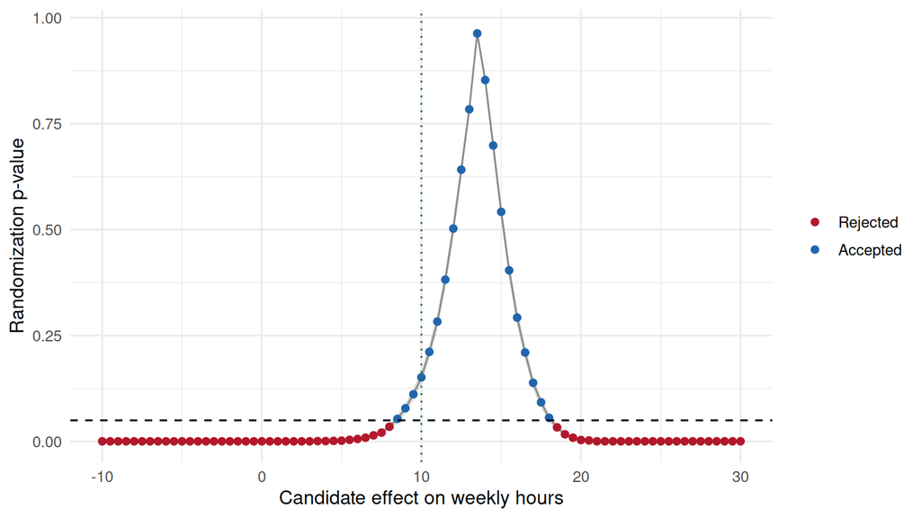

Figure 3: Monte Carlo AR tests at the evaluated week-2 candidates. The band gives 95% Monte Carlo bounds for each ideal enumeration p-value, not confidence limits for the treatment effect. Lines only guide the eye between evaluated points.

```r
ggplot(ar_table, aes(beta, p_value)) +
  geom_ribbon(aes(ymin = mc_p_lower, ymax = mc_p_upper), fill = "grey60", alpha = 0.3) +
  geom_line(color = "grey55") +
  geom_point(aes(color = accepted), size = 1.8) +
  geom_hline(yintercept = 0.05, linetype = "dashed") +
  geom_vline(xintercept = true_beta_duration, color = "#1b7837", linetype = "dotted") +
  scale_color_manual(values = c("FALSE" = "#b2182b", "TRUE" = "#2166ac"),
                     labels = c("Rejected", "Accepted")) +
  labs(x = "Candidate effect on weekly hours", y = "Randomization p-value", color = NULL)
```

## 8 How sensitive is the conclusion to direct encouragement effects?

Suppose concierge advice can improve engagement without tool activation. For a binary outcome, `encouragement_bounds()` allows bounds on the direct encouragement effect within principal strata, under monotonicity. We use the prespecified business target of at least 85 active-user hours in week 2. This changes the estimand to an effect on the probability of meeting that target; it is not a rescaling of the continuous-hours effect.

We vary $\delta$, the maximum absolute direct effect on outcome probability, from zero to 0.20. For example, $\delta=0.10$ permits up to **10 percentage points**, not a 10% relative change. A scalar applies the same bound to the always-adopter, non-adopter, and complier strata at this horizon.

```r
y_success <- as.numeric(y[, t_enc] >= success_threshold)
delta_grid <- c(0, 0.025, 0.05, 0.10, 0.15, 0.20)
bounds_table <- bind_rows(lapply(delta_grid, function(delta_value) {
  result <- encouragement_bounds(
    y = y_success, d = d[, t_enc], z = z_unit, delta = delta_value,
    draws = 2000L, chains = 2L, seed = 42L
  )
  mutate(result$table, delta = delta_value)
}))
bounds_example <- filter(bounds_table, estimand == "treatment_z0", delta == 0.10)
bounds_table %>%
  filter(estimand == "treatment_z0") %>%
  select(delta, lower_median, upper_median, lower_ci_lower, upper_ci_upper,
         compatible_fraction, available_fraction) %>%
  kable(digits = 3,
        col.names = c("Direct-effect limit", "Median lower bound", "Median upper bound",
                      "Lower endpoint 2.5%", "Upper endpoint 97.5%", "Compatible", "Available"))
```

| Direct-effect limit | Median lower bound | Median upper bound | Lower endpoint 2.5% | Upper endpoint 97.5% | Compatible | Available |
| --- | --- | --- | --- | --- | --- | --- |
| 0.000 | 0.210 | 0.210 | 0.069 | 0.333 | 0.968 | 0.968 |
| 0.025 | 0.176 | 0.251 | 0.031 | 0.374 | 0.988 | 0.988 |
| 0.050 | 0.147 | 0.290 | -0.001 | 0.411 | 0.995 | 0.995 |
| 0.100 | 0.093 | 0.363 | -0.049 | 0.480 | 1.000 | 1.000 |
| 0.150 | 0.042 | 0.429 | -0.075 | 0.542 | 1.000 | 1.000 |
| 0.200 | -0.009 | 0.492 | -0.090 | 0.602 | 1.000 | 1.000 |

The table focuses on the adoption effect among compliers with encouragement held at zero (`treatment_z0`). The other reported estimands are the adoption effect with encouragement held at one (`treatment_z1`) and the joint encouragement-and-adoption effect among compliers (`complier_encouragement`). They coincide under strict exclusion; they can differ when direct effects are allowed.

At $\delta=0.10$, the median identification endpoints are [0.093, 0.363]. The outer endpoint-uncertainty envelope is [-0.049, 0.480]. Both summaries matter when judging whether a positive adoption effect is supported under the allowed direct effect.

Two uncertainties appear in Figure 4. The solid curves are posterior medians of the lower and upper identification bounds. Their separation reflects partial identification. The pale band spans the lower endpoint’s 2.5% quantile to the upper endpoint’s 97.5% quantile, adding uncertainty about the bounds themselves. It is not a calibrated frequentist confidence interval. Under strict exclusion, the draw-specific bounds collapse to a point when available, while uncertainty across posterior draws remains.

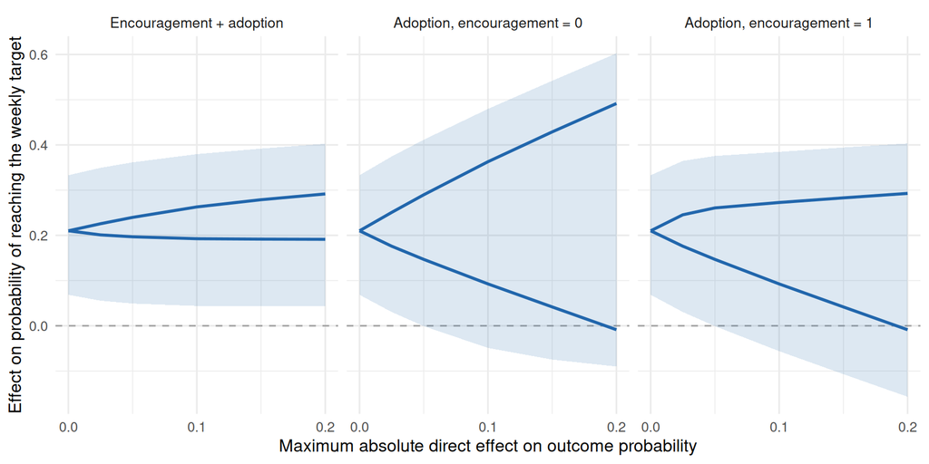

Figure 4: Sensitivity of three complier estimands to permitted direct encouragement effects. Solid lines show median identification endpoints; shading shows an outer envelope of endpoint posterior quantiles, conditional on available draws.

```r
bounds_plot <- bounds_table %>%
  mutate(estimand = factor(estimand,
    levels = c("complier_encouragement", "treatment_z0", "treatment_z1"),
    labels = c("Encouragement + adoption", "Adoption, encouragement = 0",
               "Adoption, encouragement = 1")))
ggplot(bounds_plot, aes(delta)) +
  geom_hline(yintercept = 0, color = "grey65", linetype = "dashed") +
  geom_ribbon(aes(ymin = lower_ci_lower, ymax = upper_ci_upper),
              fill = "#2166ac", alpha = 0.15) +
  geom_line(aes(y = lower_median), color = "#2166ac", linewidth = 1) +
  geom_line(aes(y = upper_median), color = "#2166ac", linewidth = 1) +
  facet_wrap(~ estimand, nrow = 1) +
  scale_x_continuous(breaks = c(0, 0.10, 0.20)) +
  labs(x = "Maximum absolute direct effect on outcome probability",
       y = "Effect on probability of reaching the weekly target") +
  theme(strip.text = element_text(size = 10))
```

The package constructs sharp principal-stratum bounds for each draw of the binary cell probabilities under its specified restrictions. `compatible_fraction` is the fraction of those draws compatible with the restrictions; `available_fraction` also requires a defined, positive complier share. Endpoint summaries condition on available draws. Report these fractions with the bounds: a small fraction changes how much of the fitted probability distribution is represented.

Neither fraction is a p-value or an automatic rejection test. At later horizons, a small compatibility fraction could reflect a mismatch between static exclusion and treatment histories, among other explanations. It does not uniquely diagnose duration effects. We therefore keep this sensitivity exercise at week 2, where the current-adoption interpretation is coherent in the simulation.

## 9 Does smoothing improve on simpler IV estimators?

A more flexible model earns its extra complexity by improving inference for the same target. We therefore evaluate the repaired direct-smoothing backend against three alternatives: assigned-arm mean differences, linear covariate-adjusted reduced forms, and spline covariate-adjusted reduced forms. The adjusted methods fit each assignment arm separately, adjust for baseline outcomes and the same measured covariates, and standardize to the same accounts. Their ratio confidence sets use the joint HC2 covariance and preserve the complete Fieller set.

This comparison uses **100 independent experiments in each of six prespecified scenarios**, with 160 accounts, two baseline weeks and four follow-up weeks. Both potential-outcome panels are fixed before complete randomization. Unlike the accelerating-adoption example above, these experiments specify outcomes as a function of current adoption, so the evaluated current-adoption CACE has a valid interpretation. The strong-stage scenarios have linear, nonlinear smooth, or abruptly changing effects. Weak relevance, no relevance, and serially correlated heteroskedastic errors test important limits.

LongBet uses four chains, 500 warmup iterations and 1,000 retained draws per chain, four baseline and four effect trees, and independent unit intercepts. Pilot seeds are separate from the evaluation seeds. Every fit, failure, horizon, interval and convergence result is retained. Passing diagnostics requires all reported ITTs and ratios to pass. Zero-relevance CACE is undefined and is not scored against an invented zero effect.

The prespecified accuracy criterion is at least a 10% reduction in CACE root mean squared error (RMSE), with a paired-bootstrap upper confidence limit below one for the RMSE ratio against **both** adjusted comparators. The bootstrap resamples experiments and keeps their horizons together. Continuation also requires at least 95% of fits to pass diagnostics and satisfactory pointwise coverage. These are scenario-specific comparisons, not simultaneous evidence of superiority across every possible design.

```r
comparison <- read.csv("iv-comparison/aggregate.csv")
paired_comparison <- read.csv("iv-comparison/paired-comparisons.csv")
comparison_methods <- c(
  unadjusted = "Unadjusted IV", linear_ancova = "Linear adjusted IV",
  spline_ancova = "Spline adjusted IV", longbet_direct = "LongBet direct"
)
comparison_scenarios <- c(
  linear = "Linear", smooth = "Smooth nonlinear", abrupt = "Abrupt nonlinear",
  weak = "Weak relevance", zero = "No relevance",
  serial_heteroskedastic = "Serial / heteroskedastic"
)
comparison %>%
  filter(quantity == "wald", scenario %in% c("linear", "smooth", "abrupt")) %>%
  mutate(
    Scenario = unname(comparison_scenarios[scenario]),
    Method = unname(comparison_methods[method]),
    Coverage = sprintf("%.0f–%.0f%%", 100 * min_coverage, 100 * max_coverage),
    Diagnostics = sprintf("%d/%d", diagnostic_fits, datasets)
  ) %>%
  select(Scenario, Method, RMSE = rmse, Coverage, Diagnostics,
         `Seconds / fit` = median_seconds) %>%
  kable(digits = c(NA, NA, 3, NA, NA, 3))
```

| Scenario | Method | RMSE | Coverage | Diagnostics | Seconds / fit |
| --- | --- | --- | --- | --- | --- |
| Linear | Unadjusted IV | 1.195 | 92–95% | 100/100 | 0.002 |
| Linear | Linear adjusted IV | 0.347 | 94–98% | 100/100 | 0.001 |
| Linear | Spline adjusted IV | 0.371 | 95–98% | 100/100 | 0.001 |
| Linear | LongBet direct | 0.356 | 97–99% | 90/100 | 22.462 |
| Smooth nonlinear | Unadjusted IV | 1.341 | 94–95% | 100/100 | 0.002 |
| Smooth nonlinear | Linear adjusted IV | 0.464 | 91–97% | 100/100 | 0.000 |
| Smooth nonlinear | Spline adjusted IV | 0.409 | 92–95% | 100/100 | 0.001 |
| Smooth nonlinear | LongBet direct | 0.425 | 98–100% | 94/100 | 22.470 |
| Abrupt nonlinear | Unadjusted IV | 1.245 | 96–99% | 100/100 | 0.002 |
| Abrupt nonlinear | Linear adjusted IV | 0.470 | 88–94% | 100/100 | 0.001 |
| Abrupt nonlinear | Spline adjusted IV | 0.384 | 93–95% | 100/100 | 0.001 |
| Abrupt nonlinear | LongBet direct | 0.434 | 98–99% | 99/100 | 22.609 |

Coverage is the minimum and maximum pointwise coverage across four horizons, for nominal 95% intervals or sets. Diagnostics are the number of completed fits passing all reported checks; for reference methods, this column records completed calculations. RMSE averages squared error over all experiments and horizons before taking the square root. Runtime is the median elapsed time per method under the evaluation’s six-worker schedule.

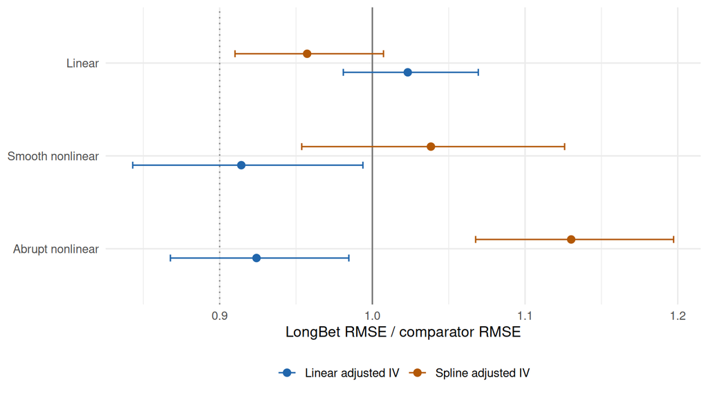

Figure 5: Paired RMSE ratios compare LongBet with each adjusted IV estimator. Values below one favor LongBet; the dotted line marks the prespecified 10% reduction. Bars show 95% experiment-level bootstrap intervals.

```r
paired_comparison %>%
  mutate(Scenario = factor(unname(comparison_scenarios[scenario]),
                           levels = rev(c("Linear", "Smooth nonlinear", "Abrupt nonlinear"))),
         Comparator = unname(comparison_methods[comparator])) %>%
  ggplot(aes(x = rmse_ratio, y = Scenario, color = Comparator)) +
  geom_vline(xintercept = 1, color = "grey45") +
  geom_vline(xintercept = 0.9, linetype = "dotted", color = "grey55") +
  geom_errorbar(aes(xmin = lower, xmax = upper), orientation = "y",
                position = position_dodge(width = 0.4), width = 0.15) +
  geom_point(position = position_dodge(width = 0.4), size = 2.5) +
  scale_color_manual(values = c("Linear adjusted IV" = "#2166ac",
                                "Spline adjusted IV" = "#b35806")) +
  labs(x = "LongBet RMSE / comparator RMSE", y = NULL, color = NULL) +
  theme(legend.position = "bottom")
```

Accuracy alone is insufficient. This second table shows LongBet’s pointwise coverage ranges for both reduced forms and their ratio, including the stress scenarios. The Gaussian adoption model treats absorbing binary observations as working continuous responses; good CACE coverage can coexist with poor adoption-ITT coverage.

```r
comparison %>%
  filter(method == "longbet_direct") %>%
  mutate(Scenario = unname(comparison_scenarios[scenario]),
         Coverage = ifelse(is.na(min_coverage), "Undefined target",
           sprintf("%.0f–%.0f%%", 100 * min_coverage, 100 * max_coverage))) %>%
  select(Scenario, quantity, Coverage) %>%
  pivot_wider(names_from = quantity, values_from = Coverage) %>%
  select(Scenario, `Outcome ITT` = itt_y, `Adoption ITT` = itt_d, CACE = wald) %>%
  kable()
```

| Scenario | Outcome ITT | Adoption ITT | CACE |
| --- | --- | --- | --- |
| Linear | 91–97% | 77–78% | 97–99% |
| Smooth nonlinear | 88–97% | 86–87% | 98–100% |
| Abrupt nonlinear | 84–99% | 80–81% | 98–99% |
| Weak relevance | 82–89% | 74–76% | 95–99% |
| No relevance | 83–95% | 76–79% | Undefined target |
| Serial / heteroskedastic | 89–99% | 89–93% | 97–100% |

Each pointwise percentage uses 100 independent experiments; the horizons are dependent observations of those experiments. With 100 experiments, a coverage estimate near 95% has a Monte Carlo standard error of about 2.2 percentage points. Reported convergence failures are retained in these raw-interval coverage calculations, so the table does not describe only the usable fits.

The complete pointwise results include coverage uncertainty and confidence-set availability for every method. The comparison report records the decision, assumptions, source hashes, and reproduction commands. The aggregate results and paired comparisons supply the numbers used here.

### 9.1 Sensitivity to correlated unit intercepts

We also enable `correlated_intercepts = TRUE` on the same 100 experiments in each strong-stage scenario. This checks the repaired joint covariance feature while retaining the tree counts, sampling budget, seeds and default proper covariance prior. The secondary protocol was added after inspecting the first 200 primary experiments, so this is an exploratory sensitivity analysis. It does not replace the primary results or test the correlated model under weak relevance.

```r
correlated_comparison <- read.csv("iv-comparison/correlated-aggregate.csv")
correlated_adoption <- correlated_comparison %>%
  filter(method == "longbet_direct", quantity == "itt_d") %>%
  transmute(scenario, `Adoption ITT coverage` =
    sprintf("%.0f–%.0f%%", 100 * min_coverage, 100 * max_coverage))
correlated_comparison %>%
  filter(method == "longbet_direct", quantity == "wald") %>%
  left_join(correlated_adoption, by = "scenario") %>%
  transmute(Scenario = unname(comparison_scenarios[scenario]),
            `CACE RMSE` = rmse,
            `CACE coverage` = sprintf("%.0f–%.0f%%", 100 * min_coverage, 100 * max_coverage),
            `Adoption ITT coverage`,
            Diagnostics = sprintf("%d/%d", diagnostic_fits, datasets)) %>%
  kable(digits = c(NA, 3, NA, NA, NA))
```

| Scenario | CACE RMSE | CACE coverage | Adoption ITT coverage | Diagnostics |
| --- | --- | --- | --- | --- |
| Linear | 0.362 | 97–99% | 82–83% | 86/100 |
| Smooth nonlinear | 0.440 | 95–99% | 90–91% | 95/100 |
| Abrupt nonlinear | 0.443 | 96–97% | 85–88% | 98/100 |

The result is negative. Neither configuration outperforms the strongest adjusted comparator in any of the three strong-stage accuracy scenarios. The independent-intercept model’s adoption-ITT coverage is only 77–87% in those scenarios. Correlated intercepts improve that coverage somewhat, but do not deliver a comparative accuracy advantage. With abrupt effects, the two LongBet configurations have about 13–15% higher CACE RMSE than spline adjusted IV. These results do not justify replacing adjusted IV with either tested configuration.

LongBet’s potential contribution is the combination of time smoothing, nonlinear covariate adjustment, and a consistent panel-analysis interface. Flexible Bayesian IV already exists in [IVBART](https://arxiv.org/html/2102.01199v1); [generalized random forests](https://arxiv.org/html/1610.01271v4) estimate heterogeneous IV effects; and [double/debiased machine learning](https://arxiv.org/html/1608.00060v7) uses orthogonal scores and cross-fitting for IV and LATE. Their identifying assumptions and targets differ. The comparisons here do not establish superiority over these unevaluated methods. Likewise, [weak-instrument-robust inference](https://onlinelibrary.wiley.com/doi/10.1111/1468-0262.00438) addresses a problem that finite posterior intervals and successful MCMC do not resolve.

## 10 Optional extensions

### 10.1 Bayesian smoothing: diagnose the quantities you report

`longbet_encourage(engine = "direct_smooth")` fits outcome and adoption reduced forms with sampled stump partitions and smooth Gaussian-process leaf effects. It adjusts for baseline covariates and shares information over time. This backend currently supports a continuous outcome and `first_stage = "lpm"`: binary adoption is a continuous working response, so fitted values need not stay between zero and one. It does not supply an absorbing adoption likelihood.

Two implementation corrections matter here. Saved ITTs now average the full-population assignment contrast, and correlated-intercept updates use the correct conditional Gaussian prior. The public Python and R wrappers now honor sampling controls and preserve the direct backend in saved models. These corrections establish what the program computes; comparative accuracy and interval coverage require separate evidence.

We run four chains with 500 warmup iterations and 1,000 retained draws each, using four baseline and four effect trees per equation. The table reports mixing for every ITT and ratio, with the default thresholds of bulk and tail ESS at least 400 and $\hat R\le1.01$. Late current-adoption ratios still lack the causal interpretation discussed above.

```r
fit_bayes <- longbet_encourage(
  y = y, d = d, z = z, x = x, t = t_grid, first_stage = "lpm",
  engine = "direct_smooth",
  direct_config = list(baseline_trees = 4L, effect_trees = 4L,
                       correlated_intercepts = FALSE),
  config = list(num_chains = 4L, num_sweeps = 1000L,
                num_burnin = 500L, random_seed = 42L)
)
pred_bayes <- predict(fit_bayes, summary_only = TRUE)
bayes_diagnostics <- pred_bayes$effects %>% filter(group == "all")
bayes_diagnostics %>%
  select(horizon, quantity, ess_bulk, ess_tail, rhat, diagnostics_passed) %>%
  kable(digits = 2,
        col.names = c("Horizon", "Quantity", "Bulk ESS", "Tail ESS", "R-hat", "Passed"))
```

| Horizon | Quantity | Bulk ESS | Tail ESS | R-hat | Passed |
| --- | --- | --- | --- | --- | --- |
| 1 | itt_y | 3721.70 | 4002.16 | 1.00 | TRUE |
| 2 | itt_y | 4048.85 | 3992.44 | 1.00 | TRUE |
| 3 | itt_y | 3826.29 | 4030.57 | 1.00 | TRUE |
| 4 | itt_y | 3383.65 | 4140.20 | 1.00 | TRUE |
| 5 | itt_y | 3625.88 | 3241.03 | 1.01 | TRUE |
| 1 | itt_d | 4154.89 | 3770.40 | 1.00 | TRUE |
| 2 | itt_d | 3943.31 | 3956.90 | 1.00 | TRUE |
| 3 | itt_d | 4019.03 | 3597.33 | 1.00 | TRUE |
| 4 | itt_d | 4204.05 | 4056.70 | 1.00 | TRUE |
| 5 | itt_d | 3804.57 | 3795.89 | 1.00 | TRUE |
| 1 | wald | 3797.15 | 4000.03 | 1.00 | TRUE |
| 2 | wald | 4116.23 | 4135.77 | 1.00 | TRUE |
| 3 | wald | 3994.47 | 3892.85 | 1.00 | TRUE |
| 4 | wald | 4133.98 | 4052.95 | 1.00 | TRUE |
| 5 | wald | 4182.11 | 3858.86 | 1.00 | TRUE |

In this run, **15 of 15** reported quantities pass the checks. The maximum finite $\hat R$ is 1.01. If checks fail, increase warmup and retained draws and compare independent runs. Inspect interval-endpoint Monte Carlo error as well as ESS. Longer runs can reduce sampling error; they cannot repair model misspecification or supply missing identification.

Use `encouragement_wald(pred_bayes)` when requesting posterior ratio summaries: it withholds estimates when the numerator, denominator, or ratio diagnostics fail. Raw summaries in `pred_bayes$effects` remain available even after a failure. Passing mixing checks does not establish interval coverage; the branch records `calibration_status = not_established` for these posterior summaries. Near-zero first-stage draws can make ratios unstable, and smoothing does not restore the missing current-adoption interpretation at late horizons.

### 10.2 Heterogeneous responses change the duration target

If the marginal response is $\beta_i$ rather than a common $\beta$, then, provided the exposure contrast is positive,

$$\frac{\mathrm{ITT}_Y(t)}{\mathrm{ITT}_S(t)}
=\frac{\sum_i\beta_i\{S_{it}(1)-S_{it}(0)\}}
{\sum_i\{S_{it}(1)-S_{it}(0)\}}.$$

This is an exposure-change-weighted average. Accounts whose exposure is unchanged receive zero weight. The weights and target can change across horizons in more general adoption patterns. A pooled duration regression has its own weighting; do not equate it automatically with an equally weighted average effect over all accounts.

```r
# A separate potential-outcome extension; the fitted main example remains constant-effect.
beta_unit <- 10 + 3 * tanh(readiness)
heterogeneous_truth <- tibble(
  period = t_grid,
  exposure_itt = colMeans(s1 - s0),
  outcome_itt = colMeans(beta_unit * (s1 - s0))
) %>%
  filter(exposure_itt > 0) %>%
  mutate(exposure_weighted_effect = outcome_itt / exposure_itt)
heterogeneous_truth %>%
  select(period, exposure_weighted_effect) %>%
  kable(digits = 2, col.names = c("Week", "True exposure-weighted marginal effect"))
```

| Week | True exposure-weighted marginal effect |
| --- | --- |
| 2 | 10.49 |
| 3 | 10.49 |
| 4 | 10.49 |
| 5 | 10.49 |
| 6 | 10.49 |

These are simulation truths, not estimated confidence intervals. The equally weighted all-account mean slope is 10.06; the exposure-weighted target describes accounts whose activation is accelerated. Unlike the main week-2 example, the heterogeneous extension does not satisfy one common sharp AR null. Exactness of that earlier test must not be transferred to this average effect.

### 10.3 Hazard modeling: when do accounts activate?

If the question concerns activation timing, `hazard_adoption_effects()` models adoption among accounts still at risk:

$$\mathcal R_t=\{i:D_{i,t-1}=0\},\qquad
h_{it}=\Pr(D_{it}=1\mid D_{i,t-1}=0,Z_i,X_i).$$

The experimental probit hazard model uses a fixed random stump basis shared across chains and a spike-and-slab relevance indicator. Its repaired sampler integrates the effect leaves when updating relevance and draws those leaves from their prior when relevance is absent. This yields evidence conditional on the chosen basis, model and prior. Calibration is unestablished, and the model does not provide weak-IV-robust outcome inference.

This implementation requires equally spaced observations and treats adoption present in the first column as a first-observation event. It does not recover earlier adoption histories. Our early adopters activate in the first observed week by construction; preexisting adopters in an actual study require an explicit history and risk-set definition.

```r
hazard_res <- hazard_adoption_effects(
  d = d, z = z, x = x, t = t_grid, trees = 4L, chains = 4L,
  burnin = 500L, draws = 1000L, seed = 42L
)
hazard_res$table %>%
  select(horizon, relevance_prob, hazard_itt_median, stock_itt_median,
         exposure_itt_median) %>%
  kable(digits = 3,
        col.names = c("Horizon", "Inclusion probability", "Hazard contrast",
                      "Adoption-stock contrast", "Exposure contrast"))
```

| Horizon | Inclusion probability | Hazard contrast | Adoption-stock contrast | Exposure contrast |
| --- | --- | --- | --- | --- |
| 1 | 1 | 0.655 | 0.552 | 0.552 |
| 2 | 1 | 0.005 | 0.550 | 1.102 |
| 3 | 1 | -0.572 | 0.047 | 1.152 |
| 4 | 1 | 0.001 | 0.048 | 1.198 |
| 5 | 1 | 0.001 | 0.047 | 1.244 |

The reported inclusion probability is 1.000; this is one model-wide indicator repeated across horizons. The table averages fitted assignment-specific hazards over the original covariate population and derives stocks and exposure from predicted survival paths. These are model-standardized quantities, rather than raw differences between observed survivors.

Hazard contrasts can change sign even under monotone adoption paths: earlier adoption removes encouraged accounts from later risk sets. The observed surviving groups are selected after assignment, so a conditional hazard contrast is not automatically a causal effect for a common survivor population. Interpret the stock and exposure predictions alongside the observed arm curves, and check sampler and prior sensitivity before relying on the model.

The separate `CoupledHazardIV` research class regresses outcomes on adoption and `D - Dhat` after fitting a hazard module. That residual is not generally a valid control function for endogenous binary adoption. At zero relevance, adoption and the residual are collinear after time effects, so a proper prior can produce a finite coefficient without identifying a causal effect. The revised class labels these as working regression coefficients and always withholds a causal interval. It is excluded from the superiority comparison.

## 11 Bring the results back to the decision

| Decision or question | Report | Assumptions and checks |
| --- | --- | --- |
| Offer concierge onboarding? | Outcome ITTs at prespecified horizons, valued against offer costs. | Respect the randomization unit and assignment scheme; exclusion is unnecessary for the offer effect. |
| Effect of current adoption? | A horizon-specific target and complete confidence set. | Establish relevance, monotonicity, and exclusion for that treatment definition; account for treatment history. |
| Value of earlier activation? | Exposure ITTs and, when justified, a structural duration response. | State the response shape, exclusion, and instrument rank; assess uncertainty with appropriate panel methods. |
| Could advice act directly? | A sensitivity curve with explicit outcome units and compatibility fractions. | Distinguish partial identification from uncertainty about its endpoints. |
| Does this model earn its added complexity? | Same-target accuracy, coverage, diagnostics, and runtime against adjusted IV. | The matched study establishes no advantage for either tested LongBet configuration. |

Prespecify the primary horizon or cumulative policy outcome. The displayed intervals are pointwise: scanning across weeks, customer subgroups, and methods does not create a simultaneous 95% guarantee. For this experiment, the lasting outcome effect of the offer and the vanishing current-adoption effect can coexist because the offer creates additional exposure time.

## Reproduce this chapter

The adjacent `render-iv.sh` uses the book’s installed Docker image and explicitly loads the R interface from the same pinned IV revision used for the Python engine. It records the resolved image ID and renders this standalone chapter. Run `bash render-iv.sh`; pass `--cache-refresh` to rerun cached fits. Changing the engine revision or image also invalidates the fit’s cache. The comparison tables read saved evaluation results; rendering does not rerun the simulation study.

```r
cat("LongBet engine revision:", Sys.getenv("LONGBET_ENGINE_REF", "not recorded"), "\n")
```

```
LongBet engine revision: 802cad26ac86f22ba59cd11860feffa556dfd896
```

```r
cat("Docker image ID:", Sys.getenv("LONGBET_RENDER_IMAGE", "not recorded"), "\n")
```

```
Docker image ID: sha256:0c1a60efa082516bf17d9479651f6ed67c1ca4955907d341f68aa6a963ac1522
```

```r
cat("R interface version:", as.character(packageVersion("longbet")), "\n")
```

```
R interface version: 1.0.0
```

```r
cat("R interface location:", find.package("longbet"), "\n")
```

```
R interface location: /tmp/iv-r-library/longbet
```

```r
cat("Python interpreter:", reticulate::py_config()$python, "\n")
```

```
Python interpreter: /opt/longbet-venv/bin/python
```

```r
cat("Python module:", reticulate::import("longbet")[["__file__"]], "\n")
```

```
Python module: /engine/src/longbet/__init__.py
```

## References

- Andrews, I., Stock, J. H., & Sun, L. (2019). [Weak instruments in instrumental variables regression: Theory and practice](https://economics.mit.edu/sites/default/files/2023-06/wirev_092218-_corrected_0.pdf). *Annual Review of Economics*, 11, 727–753.
- Angrist, J. D., Ferman, B., Gao, C., Hull, P., Tecchio, O. L., & Yeh, R. W. (2026 revision). [Instrumental variables with time-varying exposure: Dynamic effects of revascularization on quality of life](https://arxiv.org/abs/2501.01623). *arXiv:2501.01623*.
- Angrist, J. D., Imbens, G. W., & Rubin, D. B. (1996). Identification of causal effects using instrumental variables. *Journal of the American Statistical Association*, 91(434), 444–455.
- Balke, A., & Pearl, J. (1997). Bounds on treatment effects from studies with imperfect compliance. *Journal of the American Statistical Association*, 92(439), 1171–1176.
- Imbens, G. W., & Rosenbaum, P. R. (2005). Robust, accurate confidence intervals with a weak instrument: Quarter of birth and education. *Journal of the Royal Statistical Society: Series A*, 168(1), 109–126.
- Kang, H., Peck, L., & Keele, L. (2018). [Inference for instrumental variables: A randomization inference approach](https://academic.oup.com/jrsssa/article/181/4/1231/7072052). *Journal of the Royal Statistical Society: Series A*, 181(4), 1231–1254.